# Boston Armed Robberies - Time Series Analysis

December 10, 2018

## Data: Boston Armed Robberies, 1966 - 1976

Boston was a center of organized crime in the 1960's and 1970's.

- Raymond Patriarca (Boston Mafia)
- Gerrano Angiulo (Boston Mafia)
- Howard "Howie" Winter (Winter Hill Gang)

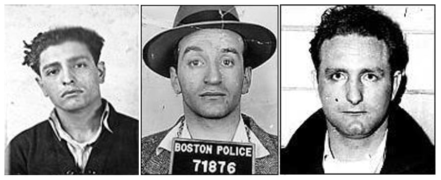

Photos from https://wikipedia.com

## Data: Boston Armed Robberies, 1966 - 1976

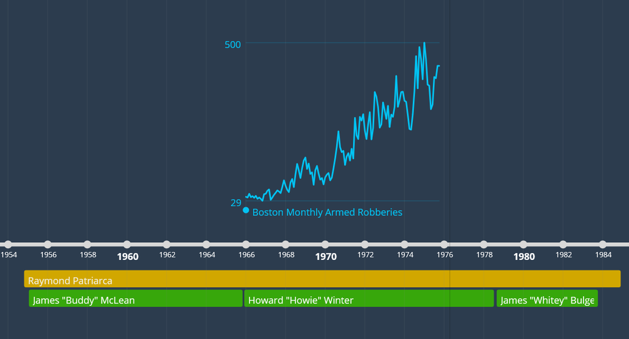

Data from https://datamarket.com/data/set/22ob/monthly-boston-armed-robberies-jan1966-oct1975-deutsch-and-alt-1977#!ds=22ob&display=line

## Data: Boston Armed Robberies, 1966 - 1976

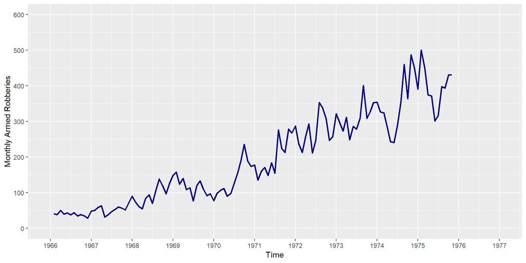

## Data: Boston Armed Robberies, 1966 - 1976

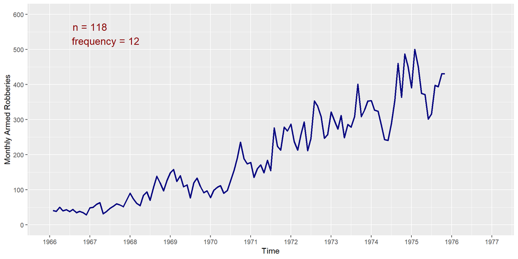

## Research Question

How much do we predict the number of monthly armed robberies to increase in the next 12 months?

## Goal: Predict 12 Steps (Months) Ahead

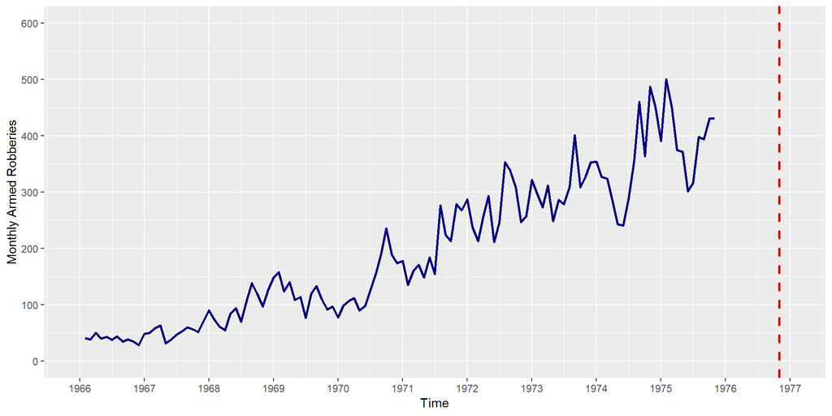

## ACF & PACF of Original Time Series

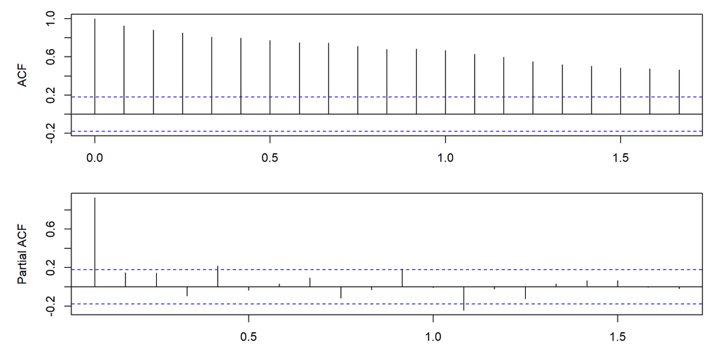

## Transform to Stationarity

1. log transformation  
2. first order differencing  
3. de-mean

## Transform to Stationarity

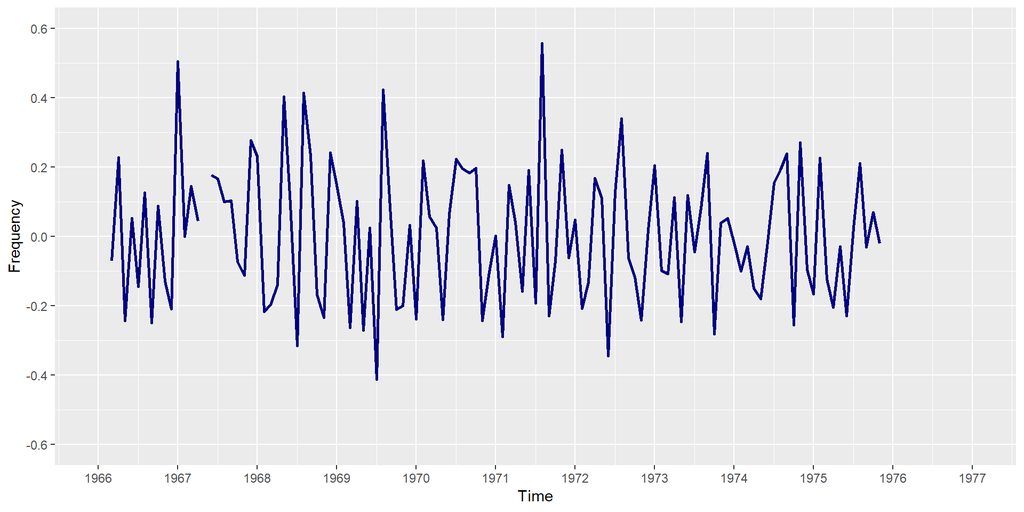

## Transform to Stationarity

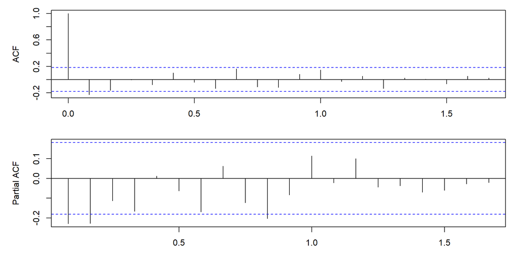

## Model Selection

The following models were considered:

| Model | \(\sigma^2\) |
| --- | --- |
| AR(2) | 0.0382 |
| MA(2) | 0.0364 |
| ARMA(1,1) | 0.0357 |
| ARMA(1,2) | 0.0357 |
| ARMA(2,1) | 0.0357 |
| ARMA(2,2) | 0.0355 |

\(\sigma^2\) is minimized for ARMA(2,2).  
ARMA(2,2) selected.

## Model Selection: ARMA(2,2)

Model appears to adequately describe the data.

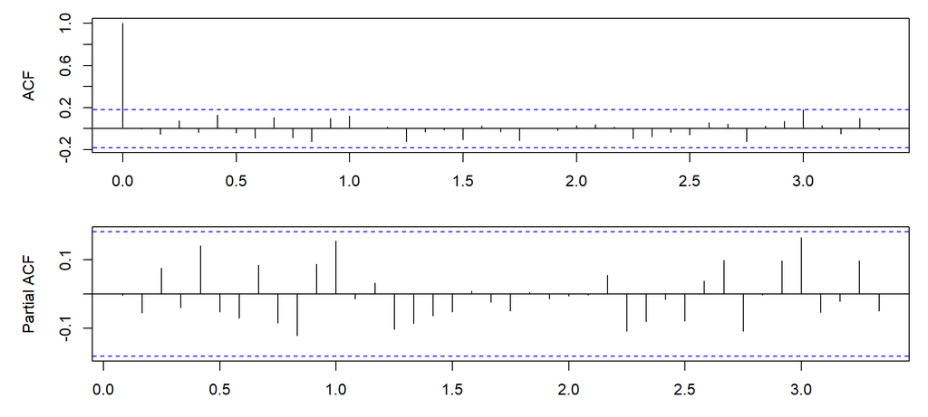

Ljung-Box Test: p-value = 0.758 for first 40 lags

## Model Selection: ARMA(2,2)

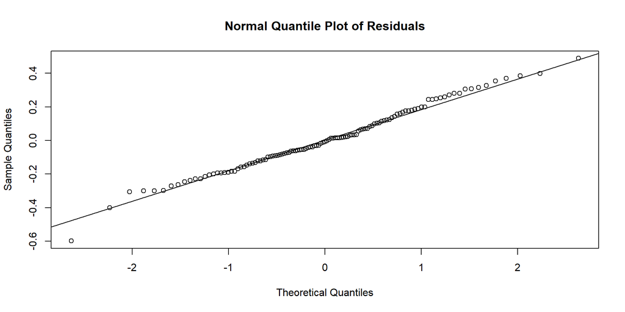

## Predictions on Stationary Time Series

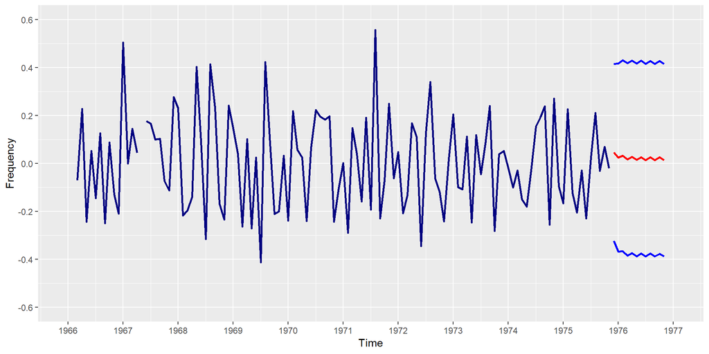

## Predictions on Stationary Time Series

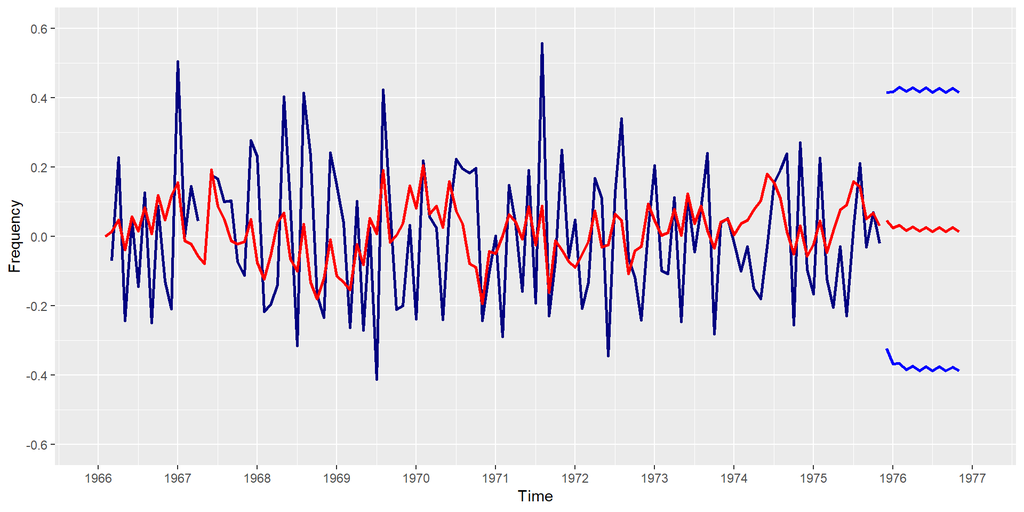

## Predictions with ARMA(2,2)

The ARMA(2,2) model does not seem to fit the data well once it has been transformed back to the original scale.

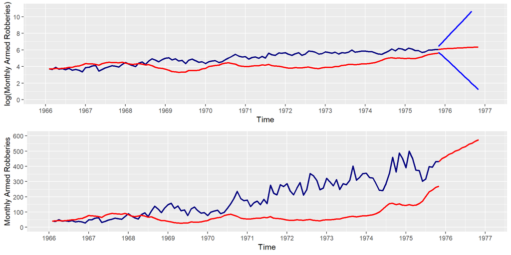

## Revisit Model Selection

The poor fit of the ARMA(2,2) model on the observed data is concerning. I will try various other models to see if any of them fit the data better when transformed back to the original scale.

The next several slides will show \(\sigma^2\), ACF/PACF, the outcome of the Ljung-Box test for various models, and the fitted model values on the differenced, log, and original scales.

## ARMA(1,2)

Model appears to adequately describe the data.

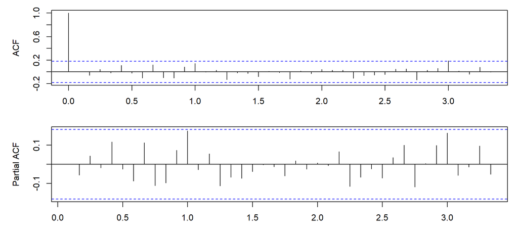

\(\sigma^2 =\) 0.0357  
Ljung-Box Test: p-value = 0.746 for first 40 lags

## ARMA(1,2) - Differenced Scale

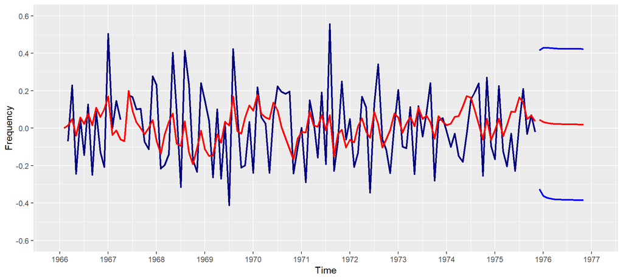

## ARMA(1,2) - Log and Original Scales

Model does not fit very well.

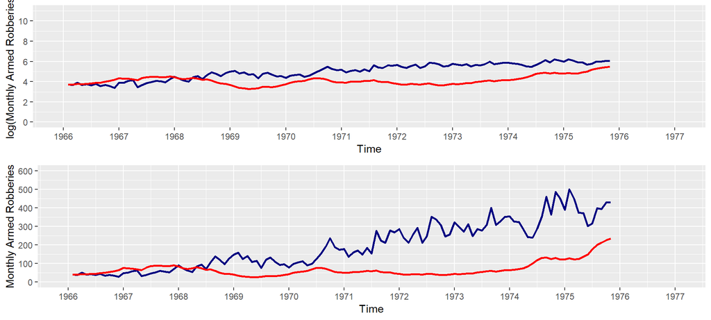

## ARMA(2,1)

Model appears to adequately describe the data.

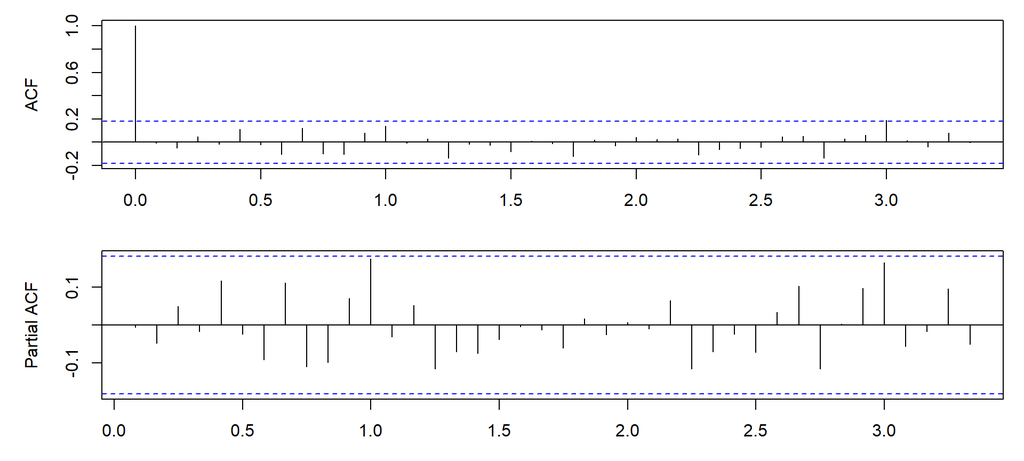

\(\sigma^2 =\) 0.0357  
Ljung-Box Test: p-value = 0.747 for first 40 lags

## ARMA(2,1) - Differenced Scale

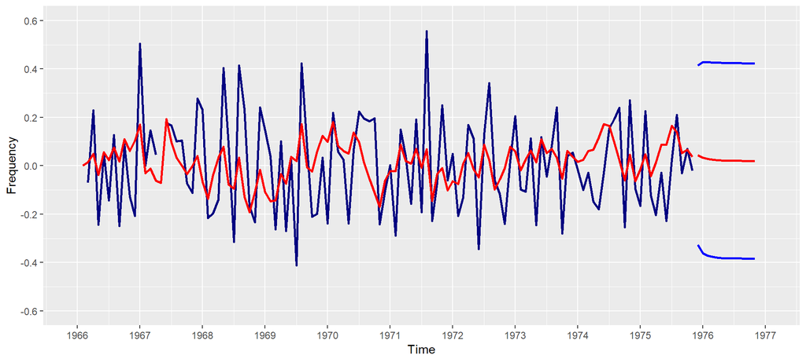

## ARMA(2,1) - Log and Original Scales

Model does not fit very well.

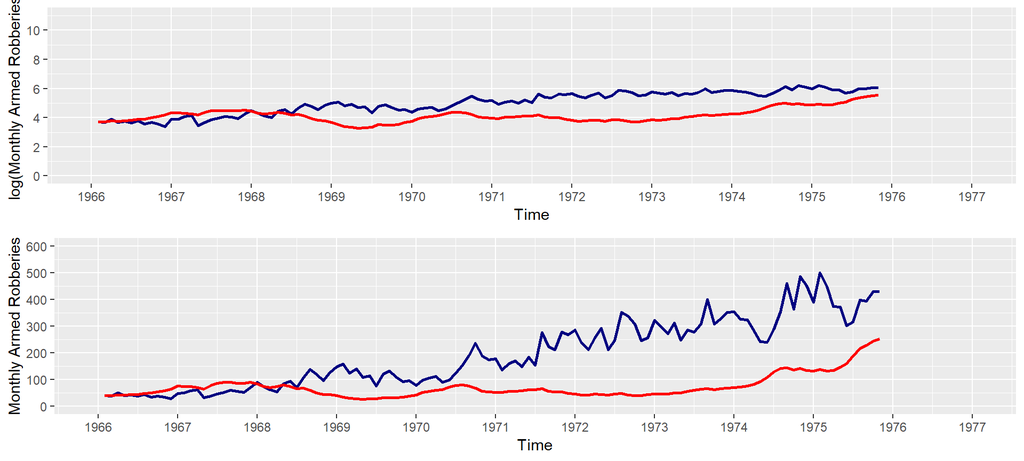

## ARMA(1,1)

Model appears to adequately describe the data.

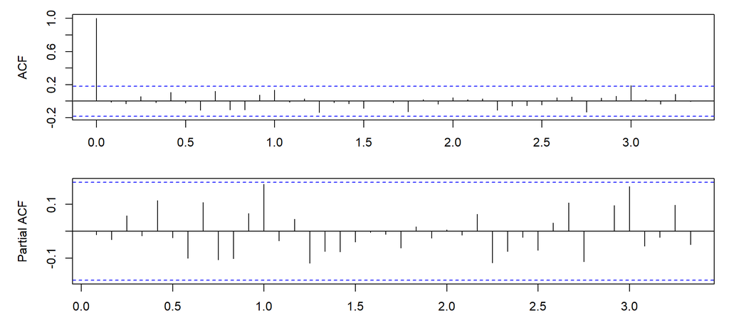

\(\sigma^2 =\) 0.0357  
Ljung-Box Test: p-value = 0.748 for first 40 lags

## ARMA(1,1) - Differenced Scale

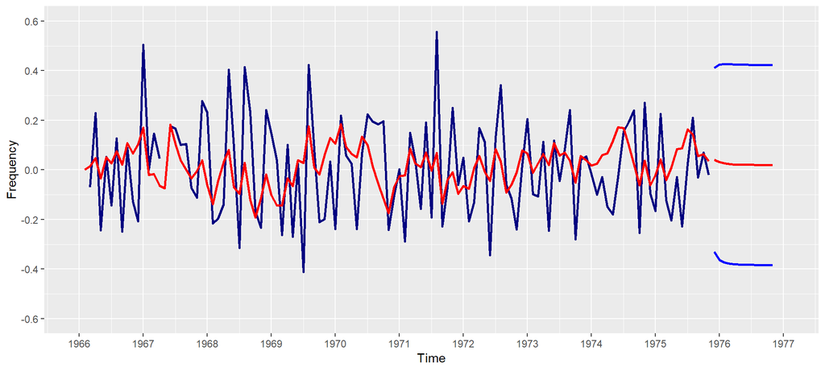

## ARMA(1,1) - Log and Original Scales

Model does not fit very well.

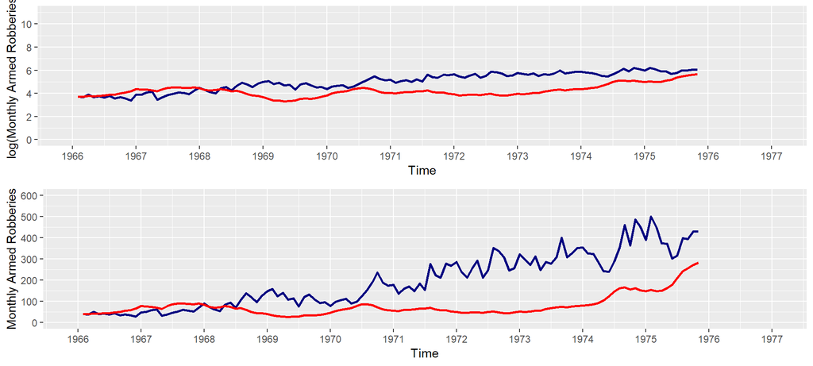

## MA(2)

Model appears to adequately describe the data.

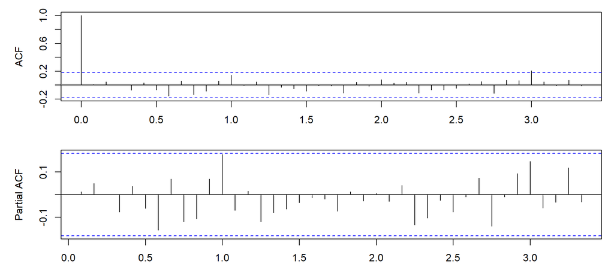

\(\sigma^2 =\) 0.0364  
Ljung-Box Test: p-value = 0.625 for first 40 lags

## MA(2) - Differenced Scale

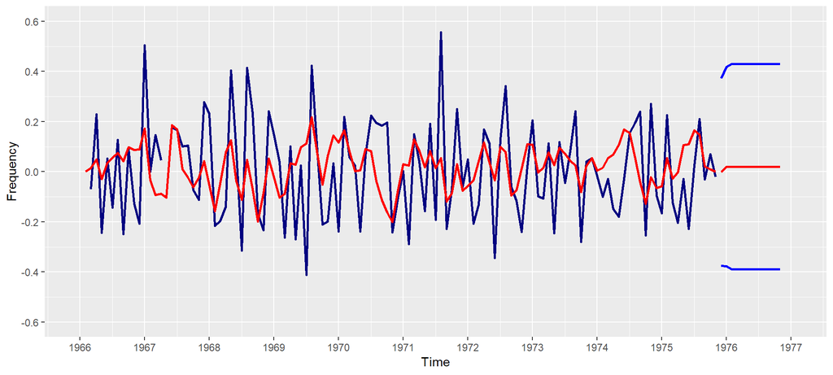

## MA(2) - Log and Original Scales

Model fits somewhat well.

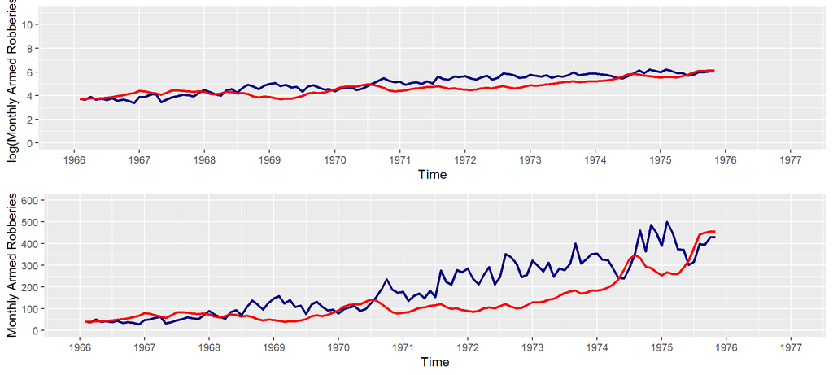

## AR(2)

Model appears to adequately describe the data.

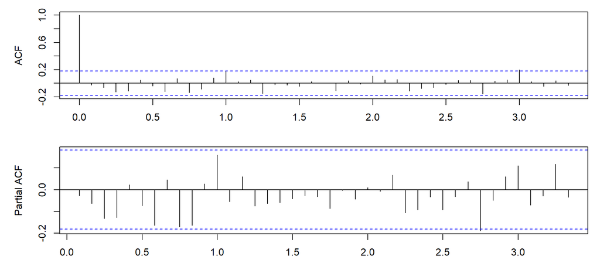

\(\sigma^2 =\) 0.0382  
Ljung-Box Test: p-value = 0.427 for first 40 lags

## AR(2) - Differenced Scale

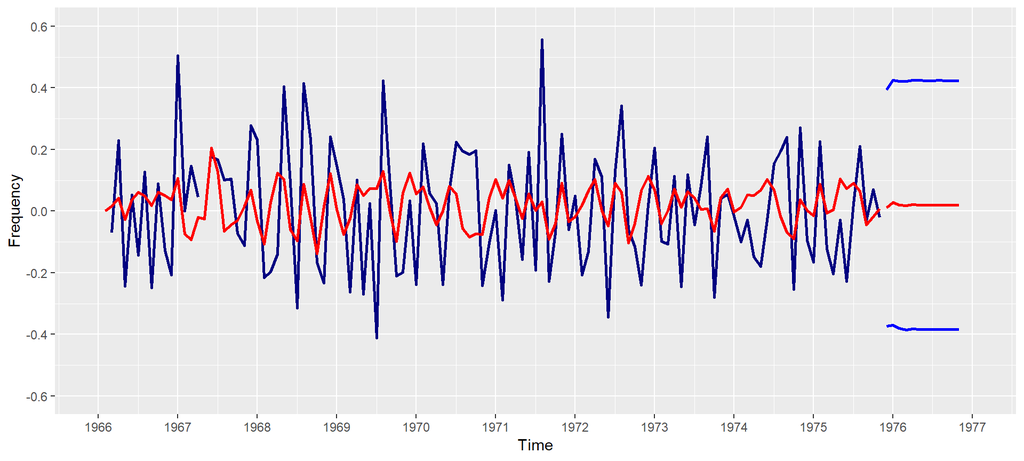

## AR(2) - Log and Original Scales

Model fits quite well (definitely better than previously considered models).

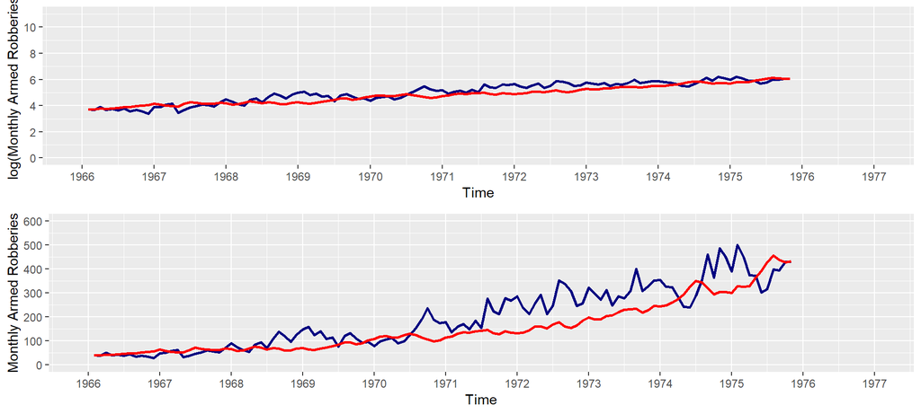

## Model Selection (Round 2)

Since the \(\sigma^2\) values are all relatively close together (0.035 to 0.038), not much predictive power is lost between the various models. After viewing the PACF, ACF, and particularly the fitted values (transformed back to the original scale), it is clear to me that the AR(2) model fits the data best.

AR(2) will be selected as the final model.

## Predictions on Original Scale

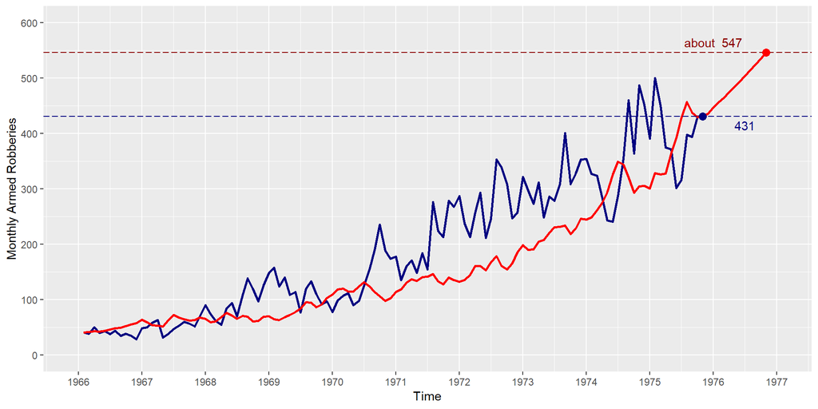

Predicted increase of **116** monthly armed robberies in the next 12 months.